GitPages site: https://dwstreit.github.io

Dave Streit

# Final Tutorial: Vinyl Release Popularity

## Intro

Since the widespread adoption of streaming, the music industry has nearly left behind one of its most historic and special artifacts, the vinyl record. However, as the COVID-19 pandemic sweeps the world and people find both more time on their hands and a strong nostalgia for the way the world was, vinyl has found itself a large resurgence in the music marketplace. With this resurgence, people have once again found a quality in vinyl records that streamed music could never have, the joy of creating a collection.

With this tutorial I hope to start what is the long-term idea of bringing vinyl record collectors the tool of a vinyl record recommendation service. While there are nearly endless services to recommend the next album for you to steam or the next playlist for you to run to, there is no notable service to tell you what’s the next vinyl to add to your collection. While this tutorial is not the full serivce, the exploration done here is the start of identifying good releases to recommend to collectors.

This tutorial uses a dataset retrieved from https://www.kaggle.com/ that contains a combination of data from https://www.discogs.com/ and Spotify. The Discogs website is geared towards vinyl collectors as a library of vinyl releases where each release is designated its own page, allowing users to view information and explore vinyl releases new and old. Since 2000, the site has accumulated nearly 2 million release submissions, cataloguing artwork, genre (albeit rigid), music style, label, and many more pieces of information per release. However, the most import aspect of Discogs to this tutorial is its want/have feature. Discogs allows users to mark releases as one they already have in their collection, or one they want to add soon. I will explain how I use this information more later, but this piece of information is most important to this tutorial as it speaks to how sought out a release is, as well as how rare the release may be. (https://www.kaggle.com/bethbaumann/first-edition-record-data-from-discogs)

Rarity and the amount a record is sought after are important aspects of a record to a collector. While some collectors may only care about finding records that match their music preferences, there are many who also seek impressive pieces to add to their collection. It is these people who would benefit most from a recommendation service of this caliber and that this tutorial is geared towards.

## Housekeeping

```python
#importing the necessary libraries to complete this tutorial
import pandas as pd
import seaborn as sns
import matplotlib.pyplot as plt
import numpy as np
from sklearn.feature_extraction import DictVectorizer
from sklearn.preprocessing import StandardScaler
from sklearn.neighbors import KNeighborsRegressor
from sklearn.pipeline import Pipeline
from sklearn.model_selection import cross_validate
from sklearn.model_selection import cross_val_score
```

## The Discogs Data

The dataset below will be the main focus of this tutorial. In this frame you will find many important pieces of information surrounding the top 1000 vinyl releases on Discogs. This information includes the artist, album, the number of albums the artist has made and the number of users who recorded having the release as well as the number of users who want the release. The frame also includes statistics such as the median price of the time since the release.

Within this frame I have also added an additional variable, Collector Value. This variable is how I will use this information in connection with the needs of a vinyl collector. The variable is simply the number of wants a release received divided by the number of people who reported having it. This variable captures the important traits I mentioned above that a collector looks for in a release by comparing the ratio of wants to haves. A higher scored release is one that had more wants than haves. This may indicate that a record is both rare and sought after, making it appealing to collectors.

This tutorial will focus mainly on analyzing this variable, and eventually attempting to predict it without knowing the haves and wants of a release.

```python
#read main release csv as dataframe
dfr = pd.read_csv('./top_1000_f.csv')


#Remove extraneous columns
del dfr['Unnamed: 0']
del dfr['artist_links']
del dfr['album_links']
del dfr['first_release_links']
del dfr['number_of_songs']
del dfr['average_song_length']
del dfr['label']
del dfr['Soundtrack']

#Remove more unnecessary columns and rearrange the order to move collector_value to a better position in the frame
cols = dfr.columns.tolist()
cols.insert(6, 'collector_value')
cols = cols[:18]
dfr['collector_value'] = dfr['users_want'] / dfr['users_have']
dfr = dfr[cols]
dfr
```

|  | artists | albums | release_country | total_artist_albums | users_have | users_want | collector_value | user_rating | median_price | styles | genres | number_for_sale | versions | spotify_monthly_listeners | time_since_sold | years_after_first_album | years_since_any_album | years_since_release |
| --- | --- | --- | --- | --- | --- | --- | --- | --- | --- | --- | --- | --- | --- | --- | --- | --- | --- | --- |
| 0 | Pink Floyd | The Dark Side Of The Moon | UK | 45.0 | 11420.0 | 7607.0 | 0.666112 | 4.67 | 246.75 | ['Prog Rock', 'Psychedelic Rock'] | ['Rock'] | 68.0 | 998.0 | 13643471.0 | 64.0 | 6.0 | 0.0 | 47.0 |
| 1 | The Beatles | Sgt. Pepper's Lonely Hearts Club Band | UK | 157.0 | 10456.0 | 4967.0 | 0.475038 | 4.55 | 110.36 | ['Rock & Roll', 'Psychedelic Rock'] | ['Rock'] | 150.0 | 918.0 | 22982890.0 | 42.0 | 4.0 | 2.0 | 53.0 |
| 2 | The Beatles | Abbey Road | UK | 157.0 | 3636.0 | 2394.0 | 0.658416 | 4.61 | 77.65 | ['Pop Rock'] | ['Rock'] | 28.0 | 720.0 | 22982890.0 | 14.0 | 6.0 | 2.0 | 51.0 |
| 3 | Pink Floyd | Wish You Were Here | UK | 45.0 | 17723.0 | 7965.0 | 0.449416 | 4.63 | 49.68 | ['Prog Rock'] | ['Rock'] | 130.0 | 729.0 | 13643471.0 | 45.0 | 8.0 | 0.0 | 45.0 |
| 4 | Michael Jackson | Thriller | US | 22.0 | 29276.0 | 6393.0 | 0.218370 | 4.50 | 13.24 | ['Disco', 'Soul'] | ['Funk / Soul', 'Pop'] | 197.0 | 552.0 | 23635338.0 | 25.0 | 10.0 | 6.0 | 38.0 |
| ... | ... | ... | ... | ... | ... | ... | ... | ... | ... | ... | ... | ... | ... | ... | ... | ... | ... | ... |
| 995 | The Beatles | The Beatles At The Hollywood Bowl | UK | 157.0 | 3352.0 | 216.0 | 0.064439 | 3.82 | 7.63 | ['Rock & Roll', 'Pop Rock', 'Beat'] | ['Rock'] | 134.0 | 129.0 | 22982890.0 | 61.0 | 14.0 | 2.0 | 43.0 |
| 996 | Fine Young Cannibals | The Raw & The Cooked | UK | 3.0 | 3265.0 | 251.0 | 0.076876 | 3.81 | 4.33 | ['Synth-pop', 'Alternative Rock', 'Pop Rock'] | ['Electronic', 'Rock', 'Funk / Soul', 'Pop'] | 125.0 | 114.0 | 2248877.0 | 37.0 | 3.0 | 32.0 | 32.0 |
| 997 | Elton John | A Single Man | UK | 139.0 | 2583.0 | 129.0 | 0.049942 | 3.63 | 3.50 | ['Soft Rock', 'Pop Rock'] | ['Rock', 'Pop'] | 331.0 | 127.0 | 23907107.0 | 40.0 | 9.0 | 1.0 | 42.0 |
| 998 | David Bowie | Never Let Me Down | UK | 87.0 | 1647.0 | 288.0 | 0.174863 | 3.39 | 10.45 | ['Pop Rock'] | ['Rock'] | 73.0 | 129.0 | 14064233.0 | 53.0 | 20.0 | 0.0 | 33.0 |
| 999 | Daryl Hall + John Oates | H2O | US | 52.0 | 8480.0 | 367.0 | 0.043278 | 3.71 | 4.00 | ['Pop Rock', 'Synth-pop'] | ['Electronic', 'Rock'] | 216.0 | 95.0 | 10319889.0 | 43.0 | 10.0 | 5.0 | 38.0 |

1000 rows × 18 columns

In the cell below you will see the top 10 most impressive releases to collectors from the dataset These are found by finding the 10 largest Collector Value ratios.

```python
dfr.sort_values('collector_value', ascending = False).head(10)
```

|  | artists | albums | release_country | total_artist_albums | users_have | users_want | collector_value | user_rating | median_price | styles | genres | number_for_sale | versions | spotify_monthly_listeners | time_since_sold | years_after_first_album | years_since_any_album | years_since_release |
| --- | --- | --- | --- | --- | --- | --- | --- | --- | --- | --- | --- | --- | --- | --- | --- | --- | --- | --- |
| 234 | John Coltrane | Blue Train | US | 143.0 | 179.0 | 1175.0 | 6.564246 | 4.44 | 1166.00 | ['Hard Bop'] | ['Jazz'] | NaN | 227.0 | 2163786.0 | 219.0 | 0.0 | 0.0 | 63.0 |
| 928 | Mötley Crüe | Too Fast For Love | US | 21.0 | 316.0 | 1891.0 | 5.984177 | 4.42 | 200.00 | ['Hard Rock', 'Heavy Metal'] | ['Rock'] | NaN | 153.0 | 5371425.0 | 143.0 | 0.0 | 4.0 | 39.0 |
| 746 | The Beatles | Yesterday And Today | US | 157.0 | 111.0 | 629.0 | 5.666667 | 4.58 | NaN | Psychedelic Rock | Rock | NaN | 194.0 | 22982890.0 | NaN | 3.0 | 2.0 | 54.0 |
| 102 | Nirvana | Bleach | US | 34.0 | 693.0 | 3801.0 | 5.484848 | 4.35 | 881.65 | ['Grunge'] | ['Rock'] | NaN | 302.0 | 15001321.0 | 303.0 | 0.0 | 7.0 | 31.0 |
| 165 | John Coltrane | A Love Supreme | US | 143.0 | 83.0 | 430.0 | 5.180723 | 4.92 | NaN | Free Jazz | Jazz | NaN | 230.0 | 2163786.0 | NaN | 8.0 | 0.0 | 55.0 |
| 976 | The Zombies | Odessey And Oracle | UK | 14.0 | 464.0 | 2334.0 | 5.030172 | 4.46 | 493.51 | ['Pop Rock', 'Psychedelic Rock'] | ['Rock', 'Pop'] | 14.0 | 80.0 | 2159111.0 | 58.0 | 3.0 | 5.0 | 52.0 |
| 196 | David Bowie | David Bowie | UK | 87.0 | 505.0 | 2345.0 | 4.643564 | 4.11 | 964.19 | ['Folk Rock', 'Country Rock', 'Space Rock', 'P... | ['Rock', 'Pop'] | 6.0 | 234.0 | 14064233.0 | 69.0 | 2.0 | 0.0 | 51.0 |
| 704 | John Coltrane | Giant Steps | US | 143.0 | 535.0 | 2140.0 | 4.000000 | 4.65 | 212.25 | ['Hard Bop'] | ['Jazz'] | 5.0 | 133.0 | 2163786.0 | 52.0 | 3.0 | 0.0 | 60.0 |
| 946 | The Cars | The Cars | US | 31.0 | 27.0 | 104.0 | 3.851852 | 5.00 | 11.56 | ['New Wave', 'Pop Rock', 'Synth-pop'] | ['Electronic', 'Rock'] | NaN | 161.0 | 4567427.0 | 447.0 | 0.0 | 3.0 | 42.0 |
| 837 | Vince Guaraldi | A Charlie Brown Christmas | US | 24.0 | 342.0 | 1303.0 | 3.809942 | 4.68 | 150.00 | ['Cool Jazz'] | ['Jazz'] | 6.0 | 90.0 | 109774.0 | 85.0 | 2.0 | 2.0 | 55.0 |

### Exploratory Data Analysis of the Discogs Data

Before creating the machine learning process, here is some initial exploratory analysis of the data set and the newly added Collector Value variable.

To start, I created a correlation heat map of the data set. This will show me how each variable relates to all the others in the set.

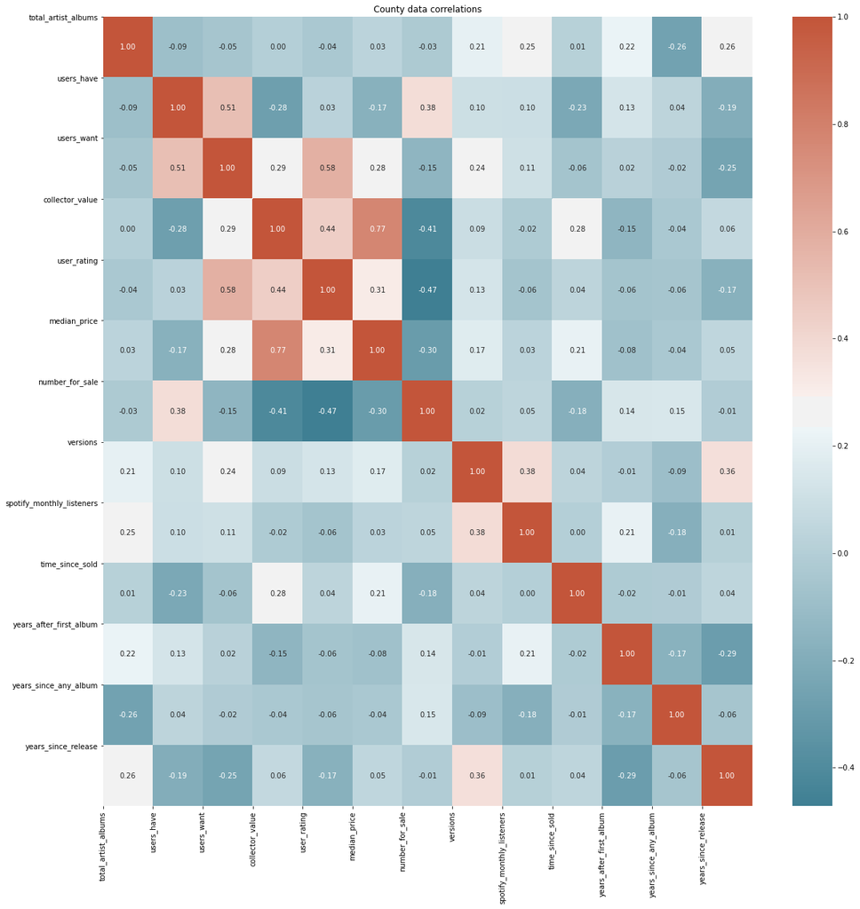

```python
corr = dfr.corr()
fig, ax = plt.subplots(figsize=(20,20))
colormap = sns.diverging_palette(220, 20, as_cmap=True)
sns.heatmap(corr, cmap=colormap, annot=True, fmt = ".2f")
plt.xticks(range(len(corr.columns)), corr.columns)
plt.yticks(range(len(corr.columns)), corr.columns)
plt.title("County data correlations")
plt.show()
```

While not many variables had strong correlations, Collector Value had the strongest and most positive relationship to another variable in the set and had some other interesting relationships as well.

The highest correlation, and the one we will explore first is Collector Value’s relationship with Median Price. This relationship contains a correlation of .77, meaning a decently strong, positive correlation. This relationship may suggest that as collectors heavily seek a release the price may go up, or collectors seek releases that are hard to find, and therefore are more expensive.

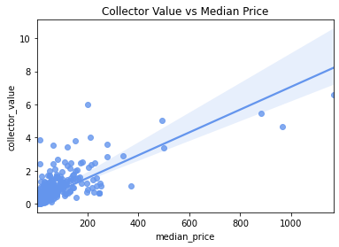

```python
fig, ax = plt.subplots()
ax.title.set_text('Collector Value vs Median Price')
sns.regplot(x="median_price", y="collector_value", data=dfr, ax=ax, fit_reg = True, color = 'cornflowerblue')
```

The other interesting correlations relating to Collector Value are its noticeable positive relationship with User Rating and negative relationship with Number for Sale. Both of these relationships show the strength of the Collector Value variable as they fit the narrative of collectors seeing value in good records that are not widely available.

The positive relationship with User Rating sugggests that as a record is more well-liked, it becomes more valuable to a collector.

The negative relationship with Number for Sale suggests that as the record is more widely available, the less valuable it becomes to a collector.

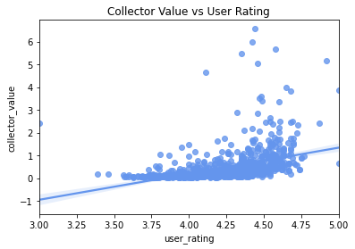

```python
#negative values are out of the scope, but provide a better view of the rest of the points in the graph
fig, ax = plt.subplots()
ax.title.set_text('Collector Value vs User Rating')
sns.regplot(x="user_rating", y="collector_value", data=dfr, ax=ax, fit_reg = True, color = 'cornflowerblue')
```

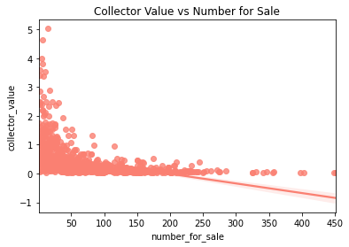

```python
#negative values are out of the scope, but provide a better view of the rest of the points in the graph
fig, ax = plt.subplots()
ax.title.set_text('Collector Value vs Number for Sale')
sns.regplot(x="number_for_sale", y="collector_value", data=dfr, ax=ax, fit_reg = True, color = 'salmon')
```

Some other interesting correlations are the positive relationship between Users Want and Users Have and the negative relationship between Number for Sale and User Rating. While these relationships are interesting, they are not very surprising. It is to be expected that a recorded with a high number of wants has a high number of haves, it means that the record is popular. Similarly, as the rating of a record increases, it is no surprise that less are for sale as people want keep records that they enjoy. This second relationship could be important moving forward as it may be another signal of a good record to recommend to a collector.

## Machine Learning

The idea behind the below machine learning program is to predict the Collector Value of a release without knowing the User Want and the User Have. To create this program, I used the top 5 most correlated features to Collector Value to train a k Nearest Neighbor regression. These variables are Median Price, User Rating, Number for Sale, Time Since Sold, and Years After First Album.

```python
dfrLearn = dfr

#remove none values to allow the learning program to run properly
dfrLearn['median_price'] = dfrLearn['median_price'].fillna(dfrLearn['median_price'].mean())
dfrLearn['user_rating'] = dfrLearn['user_rating'].fillna(dfrLearn['user_rating'].mean())
dfrLearn['number_for_sale'] = dfrLearn['number_for_sale'].fillna(dfrLearn['number_for_sale'].mean())
dfrLearn['time_since_sold'] = dfrLearn['time_since_sold'].fillna(dfrLearn['time_since_sold'].mean())
dfrLearn['years_after_first_album'] = dfrLearn['years_after_first_album'].fillna(dfrLearn['years_after_first_album'].mean())
```

Before actually predicting any values, I made sure to find the most accurate k to use in my k-Nearest Neighbors regression. Doing so ensures that my predicted Collector Value will be as accurate as possible given my features and training data.

```python
features = ['median_price', 'user_rating', 'number_for_sale', 'time_since_sold', 'years_after_first_album']
X_dict = dfrLearn[features].to_dict(orient="records")
y = dfrLearn['collector_value']


vec = DictVectorizer(sparse=False)
scaler = StandardScaler()

def get_cv_error(k):
    model = KNeighborsRegressor(n_neighbors=k)
    pipeline = Pipeline([("vectorizer", vec), ("scaler", scaler), ("fit", model)])
    mse = np.mean(-cross_val_score(
        pipeline, X_dict, y,
        cv=10, scoring="neg_mean_squared_error"
    ))
    return k,mse

ks = pd.Series(range(1, 31))
ks.index = range(1, 31)
test_errs = ks.apply(get_cv_error)

kPrime = 0
temp = 1
for x in test_errs:
    if x[1] < temp:
        kPrime = x[0]
        temp = x[1]
```

With my optimal k found, I added space to enter the data of a release in question. While this program avoids using wants and haves, some of this data still needs to be collected from Discogs given that the values in the training data for these variables comes from Discogs. For example, the predicted Collector Value would be inaccurate if number of records for sale for the release in question came from Amazon, who’s number for sale is likely much higher.

With the information entered, the Collector Value can be tested. As an example, I will predict the Collector Value of MTV Unplugged in New York by Nirvana.

```python
X_new_dict = [{
    'median_price': 28.05,
    'user_rating': 4.61,
    'number_for_sale': 1847,
    'time_since_sold': 16,
    'years_after_first_album': 31
}]

vec = DictVectorizer(sparse=False)
vec.fit(X_dict)
X_train = vec.transform(X_dict)
X_new = vec.transform(X_new_dict)

scaler = StandardScaler()
scaler.fit(X_train)
X_sc = scaler.transform(X_train)
X_new_sc = scaler.transform(X_new)

model = KNeighborsRegressor(n_neighbors=kPrime)
model.fit(X_sc, y)
predicted = model.predict(X_new_sc)
predicted[0]
```

```
0.03388249715235609
```

The model gave the album a low prediction, which makes sense when you consider the mass availablilty of MTV Unplugged. The low median price and high number for sale make the album too accessible for it to be very valuable to collector.

The real Collector Rating of MTV Unplugged:

```python
87070 / 101585
```

```
0.8571147315056357
```

## Conclusion

The creation of the k Nearest Neighbors model concludes my tutorial. While I have a working predictor of Collector Value, some good next steps would be to further build my training data and find new metrics to increase the accuracy of the model. However, I have started to process of predicted vinyls to recommend to collectors.